[figure not shown]

# LINEAIRE REGRESSIE - TOEPASSING TRENDLIJN - DISNEYLAND PARIJS

In deze notebook krijg je data voorgeschoteld van het aantal bezoekers van Disneyland Parijs.  
- Je bepaalt de mate van samenhang a.d.h.v. de correlatiecoëfficiënt.  
- Je bepaalt de vergelijking van de trendlijn.  
- Je stelt de gegeven data en de trendlijn duidelijk voor op een grafiek.

### Opdracht

Je beschikt voor deze notebook over een csv-file die cijfers hierover bevat. In de data kan je een trend waarnemen: je ziet hoe het aantal bezoekers verandert in fucntie van het jaartal.  
Je vindt het bestand in de map `data`: `eurodisney.csv`.

- Lees de data in.

Vervolgens bepaal je:

- de mate van samenhang tussen het jaartal (voor de periode 1992-**2019**) en het aantal bezoekers;
- de vergelijkingen van de regressielijn (trendlijn) voor de bezoekers in functie van het jaartal.

Tot slot stel je de gegeven data en de trendlijn duidelijk voor op een grafiek.

- Welke trend komt tevoorschijn in de data?
- Hoeveel bezoekers had men, als de trend zich had voortgezet, kunnen verwachten in 2020?
- Vergelijk dit met het werkelijk aantal bezoekers.

```
Samenhang -0.2682568161384184
Feitelijke waarde 1920
Trendlijn waarde 9151.97940295597
```

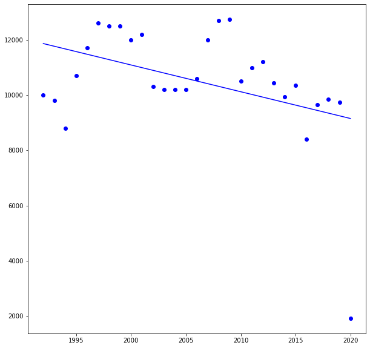

```python
import numpy as np
import pandas as pd
import matplotlib.pyplot as plt

from scipy.optimize import curve_fit

def _rechte(x, a, b):
    return a * x + b


def _linreg(x, y):
    popt, pcov = curve_fit(_rechte, x, y)

    a, b = popt
    return a, b


csv = pd.read_csv('data/eurodisney.csv')

x = np.array(csv['jaar'])
y = np.array(csv['aantal bezoekers (in 1000-tal)'])

a, b = _linreg(x, y)

samenhang = np.corrcoef(x[:-1], y[:-1])[0, 1]

print(f"Samenhang {samenhang}")
print(f"Feitelijke waarde {y[-1]}", f"\nTrendlijn waarde {_rechte(2020, a, b)}")

plt.figure(figsize=(10, 10))

plt.plot(x, _rechte(x, a, b), color="blue")
plt.scatter(x, y, color="blue")
plt.show()
```

## Referentielijst

[1] Wikipedia. (28 september 2021). Disneyland Paris. https://en.wikipedia.org/wiki/Disneyland_Paris

Notebook Python in wiskunde, zie Computationeel denken - Programmeren in Python van [AI Op School](http://www.aiopschool.be), van F. wyffels & N. Gesquière, in licentie gegeven volgens een [Creative Commons Naamsvermelding-NietCommercieel-GelijkDelen 4.0 Internationaal-licentie](http://creativecommons.org/licenses/by-nc-sa/4.0/).